# Datos, modelos y parámetros

# Zum en el 100%

- La zona del 100% es un cajón de sastre en el que se pueden identificar dos tipos de sujetos:
  - Quienes usan la tarjeta a menudo pero siempre en TPV
  - Quienes han usado la tarjeta una única vez (y fue en una TPV)
- ¡La tasa de acierto es un promedio entre las de ambos tipos de poblaciones!
- La clave es la *cantidad de información*

# Un ejemplo real

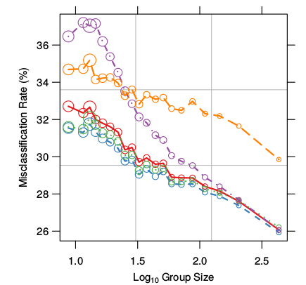

(Fuente: Perry, P.O., *Fast moment-based estimation for hierarchical models*).

# Integrando la cantidad de información en el modelo

# La idea general: dos fuentes de información

- Las dos fuentes de infomación son la de la masa y la del invididuo
- Del individuo podemos tener mucha o poca
- Nuestro modelo combina ambas:
  $$\alpha \times \text{masa} + (1-\alpha) \times \text{individuo}$$
- El parámetro $\alpha$ depende de la cantidad de información que tengamos del individuo

# Una nota sobre proporciones

- Los amateurs caculan las proporciones así:
  $$\frac{a}{a+b}$$
- Los pros las calculan, cuando menos, así:
  $$\frac{a + 0.5}{a+b+1}$$
- Eso manda los 0% y 100% espurios al entorno del 50%.
- En la página de la Wikipedia que trata de la distribución beta se justifica ese procedimiento (y se sugieren variantes).

# Inspiración bayesiana

- Existe un parámetro subyacente, $\theta$, que es la probabilidad de que el cliente use la TPV.
- Ese parámetro es desconocido y, a lo más, tenemos una idea difusa de cuál puede ser su tamaño.
- Esa idea difusa depende de:
  - Datos aprorísticos: qué hace la gente *parecida*, por ejemplo.
  - Datos de su comportamiento (¡que pueden ser pocos!)

# Probabilísticamente

- $n_i \sim \text{Binom}(N_i, \theta_i)$ donde
  - $\theta_i$ es una probabilidad asociada a cada cliente,
  - $N_i$ es el número de veces que usa la tarjeta
  - $n_i$ es el número de veces que la usa en una TPV
- Pero $\theta_i$ tiene incertidumbre que depende
  - del número de veces que se usa la tarjeta
  - de otras variables predictoras (modelo lineal)

  $$\theta_i \sim \text{Beta}(\lambda p_i, \lambda (1-p_i))$$

# Una digresión: la distribución beta

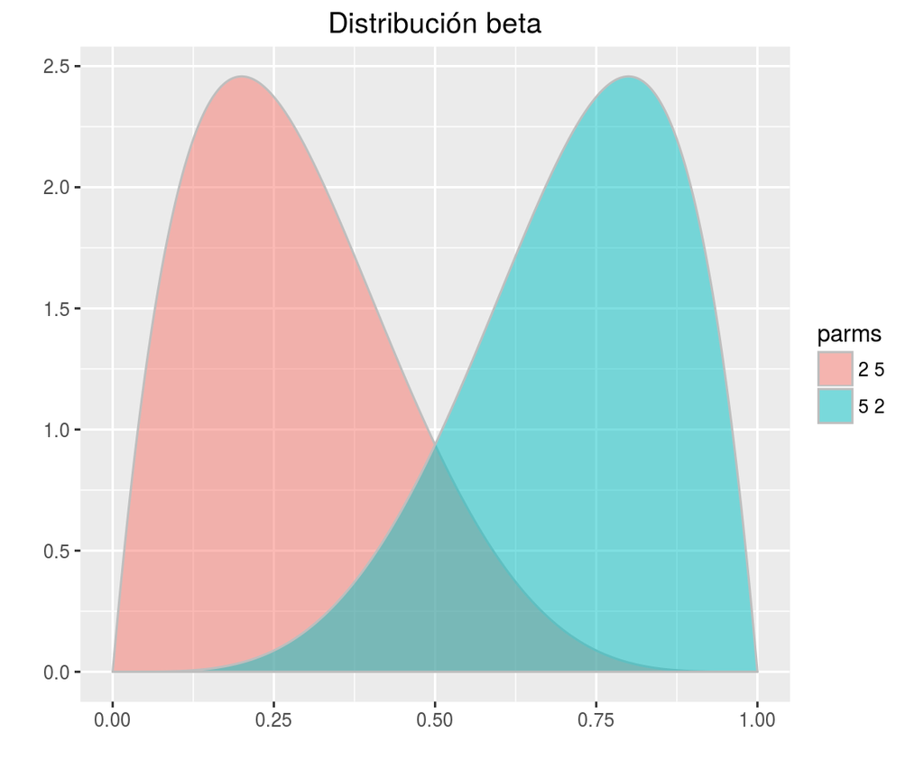

# Una digresión: la distribución beta

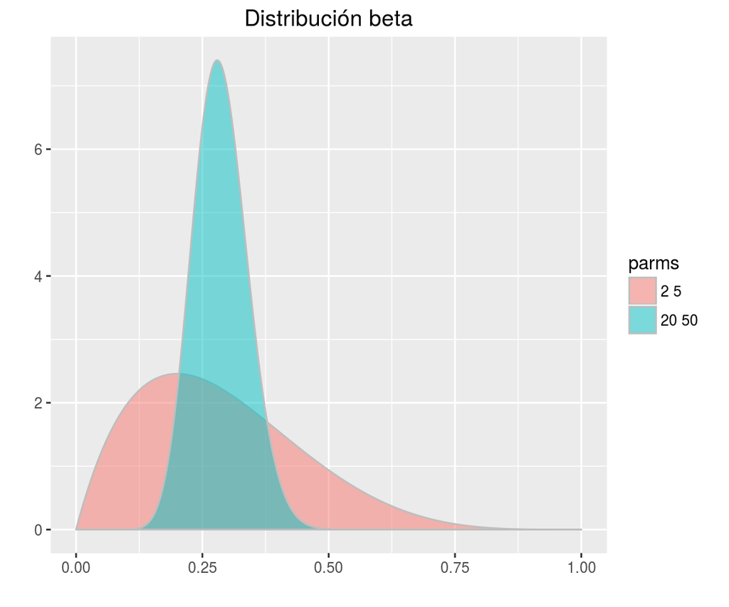

# Una digresión: la distribución beta

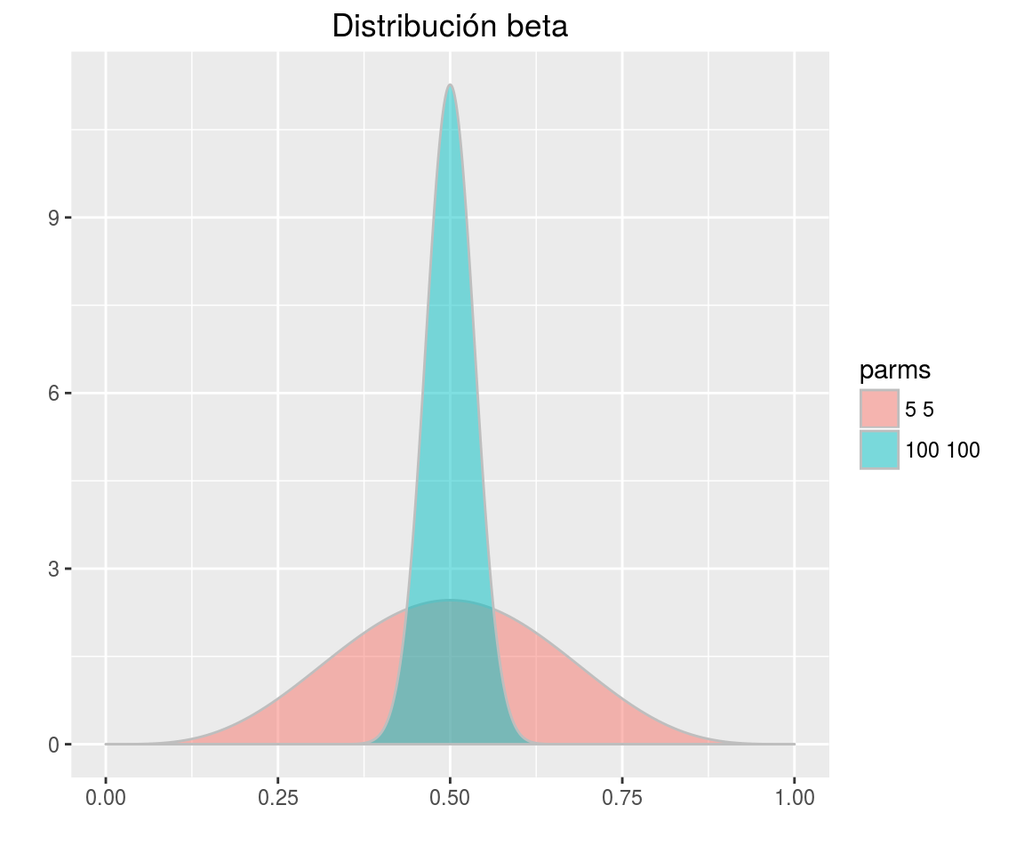

# Gráficamente

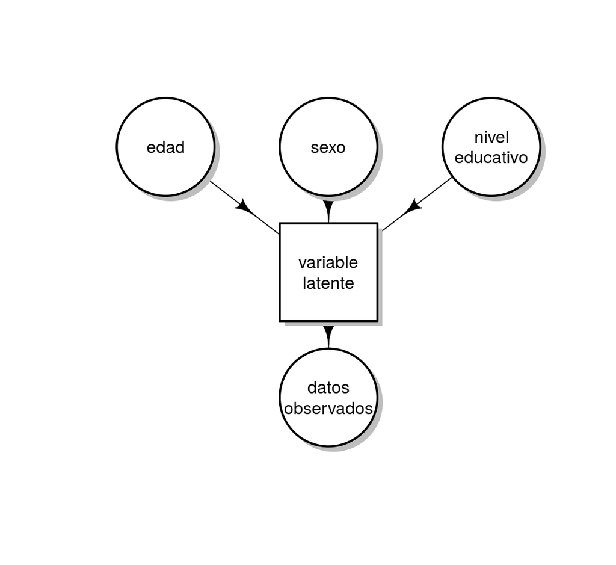

# Aunque a veces…

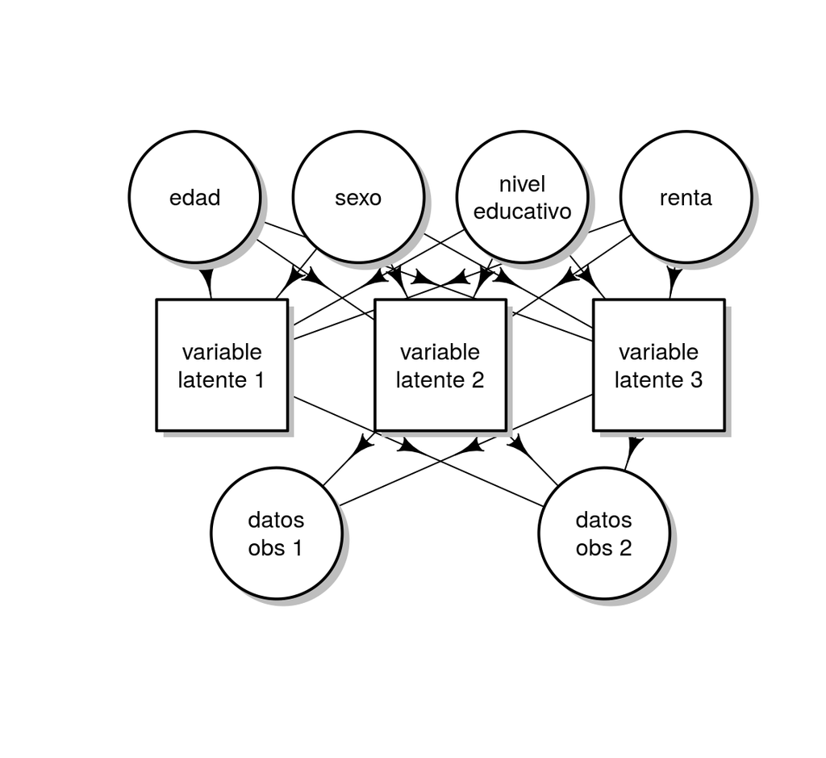

# Un modelo bayesiano

# stan (pystan, rstan, etc.)

- Es un ejemplo de lenguaje de programación probabilístico
- Está inspirado en otros previos: Jags, Bugs, etc.
- Sirve para definir la estructura probabilística de un problema (en función de parámetros desconocidos)
- Permite estimar esos parámetros desconocidos usando MCMC
- Esencialmente, encuentra valores de los parámetros compatibles con la estructura probabilística del problema

# El modelo

```r
stanmodelcode <- '
data {
  int<lower=1> N;
  int x0[N];
  int x1[N];
  int x2[N];
  int total[N];
  int tpv[N];
}

parameters {
  real<lower = 0, upper = 1> theta[N];
  real a0;
  real b1;
  real b2;
}

model {
  real a[N];
  real b[N];
  real p[N];

  for (i in 1:N){
    p[i] <- inv_logit(a0 + b1 * x1[i] + b2 * x2[i]);
    a[i] <- 0.25 + 3 * p[i];
    b[i] <- 0.25 + 3 * (1-p[i]);
  }

  theta ~ beta(a, b);
  tpv ~ binomial(total, theta);
}
'

fit <- stan(model_code = stanmodelcode,
            data = list(N = nrow(mis.datos), x0 = mis.datos$x == "a",
                        x1 = mis.datos$x == "b", x2 = mis.datos$x == "c",
                        total = mis.datos$n.usos, tpv = mis.datos$n.tpv),
            iter=12000, warmup=2000,
            chains=4, thin=10)
```

# Resultados: thetas

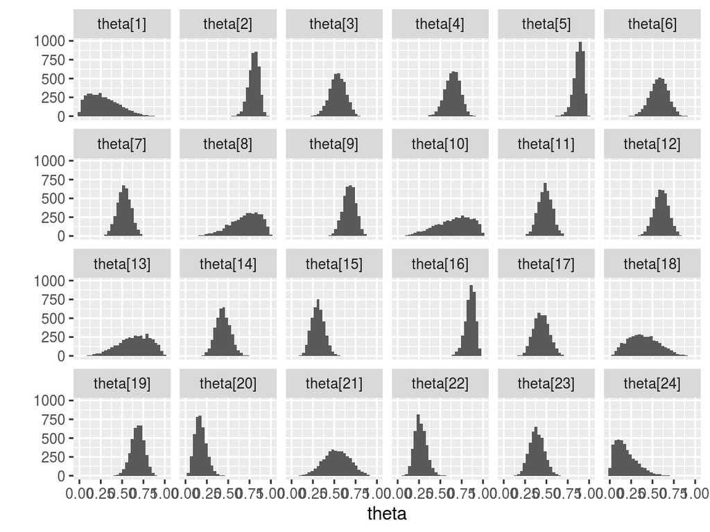

# Resultados: modelo logístico

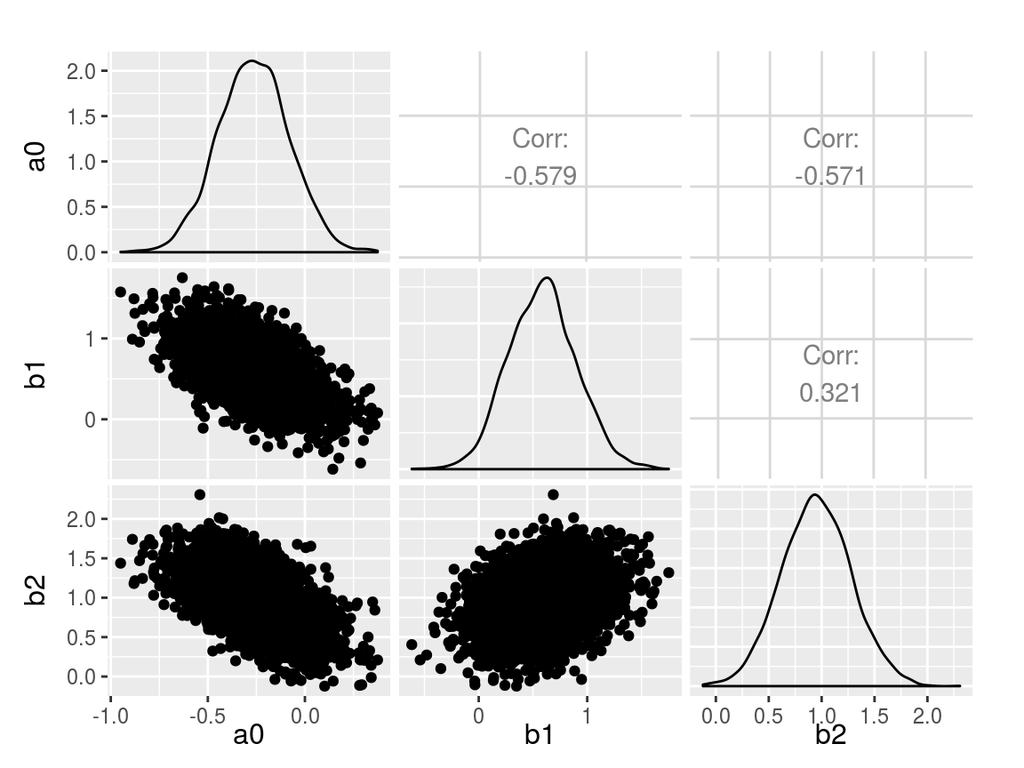

# Colofón

# Hay que ser prejuicioso

- Aunque tengan mala fama, los prejuicios son fundamentales para tomar decisiones
- Prejuicios: lo que se sabe sin necesidad de ver datos
- También se llaman *aprioris* (y tienen mala fama)
- Pero son fundamentales en contextos como el descrito hoy

# Modelos = prejuicios + datos

- Crear modelos es combinar información apriorística con datos
- Porque, a menudo, existe mucha información previa
- La aproximación bayesiana permite combinar datos y prejuicios

# Bayes es un grado

- A menudo, una aproximación 100% bayesiana es inviable (*circiter* 2016)
- La nuestra no es siquiera una aproximación 100% bayesiana
- Pero incluso en la aproximación no bayesiana pueden introducirse *toques* bayesianos

# Modelos conjuntos (“[bayesian] joint models”)

- Con la aproximación bayesiana hemos combinado dos modelos en uno:
  - Una regresión logística con las variables predictoras
  - Otro que es una especie de logística basada en el comportamiento
- Es posible construirlos por separado y *juntarlos* de una manera más o menos limpia